# Cyclic Bikeshare program Analysis 2019 -2020

Pedzisai Poseni

2023-10-11

## Setting Up the enviroment

The data sets were seperate files.As such, there was need to export them to Rstudio using the Dplyr functions and subsequently merge them into a single file ready for data analysis.The steps followed during the process are well documented in the following sections.However, before exporting, critical R packages were a prerequisite.Since they were already installed, they were only loaded to the library.These packages would unroll and install functions that are useful when conducting data exploration, cleaning and preparation for analysis.

```
## here() starts at E:/R prog files/Second project
##
##
##
##
```

## Exporting the datasets

The 4 bikeshare datasets were successfully exported into R environment through the use of the export option under the *environment tab. Since names were too long and bit confusing. It was time to rename and assign easy names that are easy to remember and recall.

## Data wrangling and combining datasets into a single file

For the purpose of cleaning the dataset and also performing analysis in R. There was need to explore the data, view its structures and determine how can it be merged into a single for. As a preparation or processing stage before the analysis stage. In order to determine this, i used the dplyr function colnames() to view all column names for the 4 datasets and noted the columns that were similar and those that needed renaming for merging purposes.This action was conducted through executing the below code chunks.

```r
colnames(bikeshare_2020_q1)
```

```
##  [1] "ride_id"            "rideable_type"      "started_at"
##  [4] "ended_at"           "start_station_name" "start_station_id"
##  [7] "end_station_name"   "end_station_id"     "start_lat"
## [10] "start_lng"          "end_lat"            "end_lng"
## [13] "member_casual"
```

```r
# These are column names for bikeshare_2020_q1
```

```r
colnames(bikeshare_2019_Q2)
```

```
##  [1] "X01...Rental.Details.Rental.ID"
##  [2] "X01...Rental.Details.Local.Start.Time"
##  [3] "X01...Rental.Details.Local.End.Time"
##  [4] "X01...Rental.Details.Bike.ID"
##  [5] "X01...Rental.Details.Duration.In.Seconds.Uncapped"
##  [6] "X03...Rental.Start.Station.ID"
##  [7] "X03...Rental.Start.Station.Name"
##  [8] "X02...Rental.End.Station.ID"
##  [9] "X02...Rental.End.Station.Name"
## [10] "User.Type"
## [11] "Member.Gender"
## [12] "X05...Member.Details.Member.Birthday.Year"
```

```r
## As i realized, the column names for this dataset were a bit different from the other 3 datsets
```

```r
colnames(bikeshare_2019_q3)
```

```
##  [1] "trip_id"           "start_time"        "end_time"
##  [4] "bikeid"            "tripduration"      "from_station_id"
##  [7] "from_station_name" "to_station_id"     "to_station_name"
## [10] "usertype"          "gender"            "birthyear"
```

The bikeshare_2019_q3 dataset had column names with information which had much resemblance to Q1, Q3 and Q4.This meant that these datasets could be successfully be merged into a single file.

```r
colnames(bikeshare_2019_q4)
```

```
##  [1] "trip_id"           "start_time"        "end_time"
##  [4] "bikeid"            "tripduration"      "from_station_id"
##  [7] "from_station_name" "to_station_id"     "to_station_name"
## [10] "usertype"          "gender"            "birthyear"
```

```r
## The bikeshare_2019_q4 shows that it has columns that are more similar to the the other datasets q1 and q3.In order for  merging to be successful, all datasets needed to have matching column names. This meant that, after data wrangling and manipulation,and renaming of the columns, these datasets can be successfully be merged into a single workable dataset.
```

## Renaming column names to match the bikeshare_2020_q1 dataset

The bikeshare_2020_q1 is the dataset i identified as the dataframe with the structure i needed in order to complete the project.As such, i had to rename all other column names to be consistent with q1_2020 data structure.This data manipulation was carried out using the below code chunk. By the way, i ran into a challenge, i executed the rename() without loading the dplyr package to RStudio. So i then loaded the package to library and wrote all codes and viola!!!

```r
str(bikeshare_2019_q3)
```

```
## 'data.frame':    1640718 obs. of  12 variables:
##  $ trip_id          : int  23479388 23479389 23479390 23479391 23479392 23479393 23479394 23479395 23479396 23479397 ...
##  $ start_time       : chr  "2019-07-01 00:00:27" "2019-07-01 00:01:16" "2019-07-01 00:01:48" "2019-07-01 00:02:07" ...
##  $ end_time         : chr  "2019-07-01 00:20:41" "2019-07-01 00:18:44" "2019-07-01 00:27:42" "2019-07-01 00:27:10" ...
##  $ bikeid           : int  3591 5353 6180 5540 6014 4941 3770 5442 2957 6091 ...
##  $ tripduration     : chr  "1,214.0" "1,048.0" "1,554.0" "1,503.0" ...
##  $ from_station_id  : int  117 381 313 313 168 300 168 313 43 43 ...
##  $ from_station_name: chr  "Wilton Ave & Belmont Ave" "Western Ave & Monroe St" "Lakeview Ave & Fullerton Pkwy" "Lakeview Ave & Fullerton Pkwy" ...
##  $ to_station_id    : int  497 203 144 144 62 232 62 144 195 195 ...
##  $ to_station_name  : chr  "Kimball Ave & Belmont Ave" "Western Ave & 21st St" "Larrabee St & Webster Ave" "Larrabee St & Webster Ave" ...
##  $ usertype         : chr  "Subscriber" "Customer" "Customer" "Customer" ...
##  $ gender           : chr  "Male" "" "" "" ...
##  $ birthyear        : int  1992 NA NA NA NA 1990 NA NA NA NA ...
```

```r
str(bikeshare_2019_q4)
```

```
## 'data.frame':    704054 obs. of  12 variables:
##  $ trip_id          : int  25223640 25223641 25223642 25223643 25223644 25223645 25223646 25223647 25223648 25223649 ...
##  $ start_time       : chr  "2019-10-01 00:01:39" "2019-10-01 00:02:16" "2019-10-01 00:04:32" "2019-10-01 00:04:32" ...
##  $ end_time         : chr  "2019-10-01 00:17:20" "2019-10-01 00:06:34" "2019-10-01 00:18:43" "2019-10-01 00:43:43" ...
##  $ bikeid           : int  2215 6328 3003 3275 5294 1891 1061 1274 6011 2957 ...
##  $ tripduration     : chr  "940.0" "258.0" "850.0" "2,350.0" ...
##  $ from_station_id  : int  20 19 84 313 210 156 84 156 156 336 ...
##  $ from_station_name: chr  "Sheffield Ave & Kingsbury St" "Throop (Loomis) St & Taylor St" "Milwaukee Ave & Grand Ave" "Lakeview Ave & Fullerton Pkwy" ...
##  $ to_station_id    : int  309 241 199 290 382 226 142 463 463 336 ...
##  $ to_station_name  : chr  "Leavitt St & Armitage Ave" "Morgan St & Polk St" "Wabash Ave & Grand Ave" "Kedzie Ave & Palmer Ct" ...
##  $ usertype         : chr  "Subscriber" "Subscriber" "Subscriber" "Subscriber" ...
##  $ gender           : chr  "Male" "Male" "Female" "Male" ...
##  $ birthyear        : int  1987 1998 1991 1990 1987 1994 1991 1995 1993 NA ...
```

## Renaming column names….. continued

```r
bikeshare_2019_q4 <- rename(bikeshare_2019_q4,
        ride_id = trip_id,
        started_at = start_time,
        ended_at = end_time,
        rideable_type = bikeid,
        start_station_id = from_station_id,
        start_station_name = from_station_name,
       end_station_id = to_station_id,
        end_station_name = to_station_name,
        member_casual = usertype)
```

```r
bikeshare_2019_q3 <- rename(bikeshare_2019_q3,
        ride_id = trip_id,
        started_at = start_time,
        ended_at = end_time,
        rideable_type = bikeid,
        start_station_id = from_station_id,
        start_station_name = from_station_name,
        end_station_id = to_station_id,
        end_station_name = to_station_name,
        member_casual = usertype)
```

```r
bikeshare_2019_q2 <- rename(bikeshare_2019_Q2,
        ride_id = "X01...Rental.Details.Rental.ID",
        rideable_type = "X01...Rental.Details.Bike.ID",
        started_at = "X01...Rental.Details.Local.Start.Time",
        ended_at = "X01...Rental.Details.Local.End.Time" ,
        start_station_name = "X03...Rental.Start.Station.Name",
        start_station_id = "X03...Rental.Start.Station.ID",

        end_station_name = "X02...Rental.End.Station.Name",
        end_station_id = "X02...Rental.End.Station.ID",
        member_casual = "User.Type")
```

After struggling with errors during my efforts to rename the columns in the datasets, i finally won! During these struggles, the key takeaways for me where as follow: +When renaming columns, make sure you start from left to right or else you will suffer - believe me, i suffered.

+Make sure and pay attention to syntax errors or typos, R is case sensitive, so make sure you copy or type as it is. standardize your naming conventions, avoid using special characters and always prefer underscores than dashes.

## Did the renaming efforts work?

Now after renaming the columns fro q2,q3 and q4 respectively, its now time to preview the data and check if the action worked.Also, this will assist in spotting any inconsistencies in the data.

```r
str(bikeshare_2019_q4)
```

```
## 'data.frame':    704054 obs. of  12 variables:
##  $ ride_id           : int  25223640 25223641 25223642 25223643 25223644 25223645 25223646 25223647 25223648 25223649 ...
##  $ started_at        : chr  "2019-10-01 00:01:39" "2019-10-01 00:02:16" "2019-10-01 00:04:32" "2019-10-01 00:04:32" ...
##  $ ended_at          : chr  "2019-10-01 00:17:20" "2019-10-01 00:06:34" "2019-10-01 00:18:43" "2019-10-01 00:43:43" ...
##  $ rideable_type     : int  2215 6328 3003 3275 5294 1891 1061 1274 6011 2957 ...
##  $ tripduration      : chr  "940.0" "258.0" "850.0" "2,350.0" ...
##  $ start_station_id  : int  20 19 84 313 210 156 84 156 156 336 ...
##  $ start_station_name: chr  "Sheffield Ave & Kingsbury St" "Throop (Loomis) St & Taylor St" "Milwaukee Ave & Grand Ave" "Lakeview Ave & Fullerton Pkwy" ...
##  $ end_station_id    : int  309 241 199 290 382 226 142 463 463 336 ...
##  $ end_station_name  : chr  "Leavitt St & Armitage Ave" "Morgan St & Polk St" "Wabash Ave & Grand Ave" "Kedzie Ave & Palmer Ct" ...
##  $ member_casual     : chr  "Subscriber" "Subscriber" "Subscriber" "Subscriber" ...
##  $ gender            : chr  "Male" "Male" "Female" "Male" ...
##  $ birthyear         : int  1987 1998 1991 1990 1987 1994 1991 1995 1993 NA ...
```

```r
str(bikeshare_2019_q3)
```

```
## 'data.frame':    1640718 obs. of  12 variables:
##  $ ride_id           : int  23479388 23479389 23479390 23479391 23479392 23479393 23479394 23479395 23479396 23479397 ...
##  $ started_at        : chr  "2019-07-01 00:00:27" "2019-07-01 00:01:16" "2019-07-01 00:01:48" "2019-07-01 00:02:07" ...
##  $ ended_at          : chr  "2019-07-01 00:20:41" "2019-07-01 00:18:44" "2019-07-01 00:27:42" "2019-07-01 00:27:10" ...
##  $ rideable_type     : int  3591 5353 6180 5540 6014 4941 3770 5442 2957 6091 ...
##  $ tripduration      : chr  "1,214.0" "1,048.0" "1,554.0" "1,503.0" ...
##  $ start_station_id  : int  117 381 313 313 168 300 168 313 43 43 ...
##  $ start_station_name: chr  "Wilton Ave & Belmont Ave" "Western Ave & Monroe St" "Lakeview Ave & Fullerton Pkwy" "Lakeview Ave & Fullerton Pkwy" ...
##  $ end_station_id    : int  497 203 144 144 62 232 62 144 195 195 ...
##  $ end_station_name  : chr  "Kimball Ave & Belmont Ave" "Western Ave & 21st St" "Larrabee St & Webster Ave" "Larrabee St & Webster Ave" ...
##  $ member_casual     : chr  "Subscriber" "Customer" "Customer" "Customer" ...
##  $ gender            : chr  "Male" "" "" "" ...
##  $ birthyear         : int  1992 NA NA NA NA 1990 NA NA NA NA ...
```

```r
str(bikeshare_2019_q2)
```

```
## 'data.frame':    1108163 obs. of  12 variables:
##  $ ride_id                                          : int  22178529 22178530 22178531 22178532 22178533 22178534 22178535 22178536 22178537 22178538 ...
##  $ started_at                                       : chr  "2019-04-01 00:02:22" "2019-04-01 00:03:02" "2019-04-01 00:11:07" "2019-04-01 00:13:01" ...
##  $ ended_at                                         : chr  "2019-04-01 00:09:48" "2019-04-01 00:20:30" "2019-04-01 00:15:19" "2019-04-01 00:18:58" ...
##  $ rideable_type                                    : int  6251 6226 5649 4151 3270 3123 6418 4513 3280 5534 ...
##  $ X01...Rental.Details.Duration.In.Seconds.Uncapped: chr  "446.0" "1,048.0" "252.0" "357.0" ...
##  $ start_station_id                                 : int  81 317 283 26 202 420 503 260 211 211 ...
##  $ start_station_name                               : chr  "Daley Center Plaza" "Wood St & Taylor St" "LaSalle St & Jackson Blvd" "McClurg Ct & Illinois St" ...
##  $ end_station_id                                   : int  56 59 174 133 129 426 500 499 211 211 ...
##  $ end_station_name                                 : chr  "Desplaines St & Kinzie St" "Wabash Ave & Roosevelt Rd" "Canal St & Madison St" "Kingsbury St & Kinzie St" ...
##  $ member_casual                                    : chr  "Subscriber" "Subscriber" "Subscriber" "Subscriber" ...
##  $ Member.Gender                                    : chr  "Male" "Female" "Male" "Male" ...
##  $ X05...Member.Details.Member.Birthday.Year        : int  1975 1984 1990 1993 1992 1999 1969 1991 NA NA ...
```

As seen above through the use of str(), can see that the column names were successfully renamed and now are consistent wit names in the bikeshare_2020_q1 which i will use as the base data frame in this project below.

```r
str(bikeshare_2020_q1)
```

```
## 'data.frame':    426887 obs. of  13 variables:
##  $ ride_id           : chr  "EACB19130B0CDA4A" "8FED874C809DC021" "789F3C21E472CA96" "C9A388DAC6ABF313" ...
##  $ rideable_type     : chr  "docked_bike" "docked_bike" "docked_bike" "docked_bike" ...
##  $ started_at        : chr  "2020-01-21 20:06:59" "2020-01-30 14:22:39" "2020-01-09 19:29:26" "2020-01-06 16:17:07" ...
##  $ ended_at          : chr  "2020-01-21 20:14:30" "2020-01-30 14:26:22" "2020-01-09 19:32:17" "2020-01-06 16:25:56" ...
##  $ start_station_name: chr  "Western Ave & Leland Ave" "Clark St & Montrose Ave" "Broadway & Belmont Ave" "Clark St & Randolph St" ...
##  $ start_station_id  : int  239 234 296 51 66 212 96 96 212 38 ...
##  $ end_station_name  : chr  "Clark St & Leland Ave" "Southport Ave & Irving Park Rd" "Wilton Ave & Belmont Ave" "Fairbanks Ct & Grand Ave" ...
##  $ end_station_id    : int  326 318 117 24 212 96 212 212 96 100 ...
##  $ start_lat         : num  42 42 41.9 41.9 41.9 ...
##  $ start_lng         : num  -87.7 -87.7 -87.6 -87.6 -87.6 ...
##  $ end_lat           : num  42 42 41.9 41.9 41.9 ...
##  $ end_lng           : num  -87.7 -87.7 -87.7 -87.6 -87.6 ...
##  $ member_casual     : chr  "member" "member" "member" "member" ...
```

Looking at the column names for all the data frames and in comparison with the base data frame (bikeshare_2020_q1), i noticed that the ## ride_id and ## rideable_type columns should be a character data type than an integer.All the 3 datasets had these two columns as integer as seen above. Therefore i had to convert the data type from integer to character through employing the mutate(). This would allow the data to be merged easily since each column should have one data type.Before doing that, needed to load dplyr to the enviroment and avoid errors in the end.

```r
library(dplyr)
```

## Converting data types from numeric to character type

```r
# rideable_type and ride_id in q2, q3 and q4 were converted to character data type.

bikeshare_2019_q2 <- mutate(bikeshare_2019_q2,ride_id = as.character(ride_id),
                            rideable_type = as.character(rideable_type))

bikeshare_2019_q3 <- mutate(bikeshare_2019_q3, ride_id = as.character(ride_id),
                            rideable_type = as.character(rideable_type))

bikeshare_2019_q4 <- mutate(bikeshare_2019_q4, ride_id =as.character(ride_id),
                          rideable_type = as.character(rideable_type))
```

## Lets merge!!

Now that i finished cleaning up and tidying the data in preparation for merging only (though still have some more tiding to do in preparation for analysis), the datasets are now consistently named and with consistent data types. Therefore, now merging into one dataset called #cyclistic_biketrips# is possible and then drop some columns which are not needed and were peculiar 2019 datasets only *lat, long, birthyear, and gender fields).

```r
cyclistic_biketrips <- bind_rows(bikeshare_2019_q2,bikeshare_2019_q3,bikeshare_2019_q4,bikeshare_2020_q1)
```

## Removing unwanted columns

```r
cyclistic_biketrips <- select(cyclistic_biketrips,
  - "start_lat",
  - "start_lng",
  - "end_lat",
  - "end_lng",
  - "birthyear",
  - "gender",
  - "X01...Rental.Details.Duration.In.Seconds.Uncapped",
  - "X05...Member.Details.Member.Birthday.Year",
  - "Member.Gender",
  - "tripduration")
```

```r
str(cyclistic_biketrips)
```

```
## 'data.frame':    3879822 obs. of  9 variables:
##  $ ride_id           : chr  "22178529" "22178530" "22178531" "22178532" ...
##  $ started_at        : chr  "2019-04-01 00:02:22" "2019-04-01 00:03:02" "2019-04-01 00:11:07" "2019-04-01 00:13:01" ...
##  $ ended_at          : chr  "2019-04-01 00:09:48" "2019-04-01 00:20:30" "2019-04-01 00:15:19" "2019-04-01 00:18:58" ...
##  $ rideable_type     : chr  "6251" "6226" "5649" "4151" ...
##  $ start_station_id  : int  81 317 283 26 202 420 503 260 211 211 ...
##  $ start_station_name: chr  "Daley Center Plaza" "Wood St & Taylor St" "LaSalle St & Jackson Blvd" "McClurg Ct & Illinois St" ...
##  $ end_station_id    : int  56 59 174 133 129 426 500 499 211 211 ...
##  $ end_station_name  : chr  "Desplaines St & Kinzie St" "Wabash Ave & Roosevelt Rd" "Canal St & Madison St" "Kingsbury St & Kinzie St" ...
##  $ member_casual     : chr  "Subscriber" "Subscriber" "Subscriber" "Subscriber" ...
```

```r
# bow can see the unwanted columns were successfully deleted from the newly created data frame cyclistic_biketrips.Now  i was happy that i had a clean and merged dataset which can now be cleaned in preparation for analysis.
```

## Clean data and prepare for data analysis

During this stage i realy wanted to view my data and understand the new structure and also confirm all the previous cleaning i undertook. i used quite a number of functions to allow me to view the dataset in all dimensions. However, iam not going to show the output here intentionally to try and shorten the notebook which is becoming too big.But in a nutshell, the functions i used to inspect the data and understand its depths as follows:

colnames(cyclistic_biketrips) #List of column names nrow(cyclistic_biketrips) #How many rows are in data frame? dim(cyclistic_biketrips) #Dimensions of the data frame? head(cyclistic_biketrips) #See the first 6 rows of data frame. str(cyclistic_biketrips) #See list of columns and data types (numeric, character, etc) summary(cyclistic_biketrips) #Statistical summary of data. Mainly for numerics Only a few will show output here:

```r
colnames(cyclistic_biketrips)
```

```
## [1] "ride_id"            "started_at"         "ended_at"
## [4] "rideable_type"      "start_station_id"   "start_station_name"
## [7] "end_station_id"     "end_station_name"   "member_casual"
```

```r
# as you can see all unwanted columns are removed and have only 9 columns
```

```r
str(cyclistic_biketrips)
```

```
## 'data.frame':    3879822 obs. of  9 variables:
##  $ ride_id           : chr  "22178529" "22178530" "22178531" "22178532" ...
##  $ started_at        : chr  "2019-04-01 00:02:22" "2019-04-01 00:03:02" "2019-04-01 00:11:07" "2019-04-01 00:13:01" ...
##  $ ended_at          : chr  "2019-04-01 00:09:48" "2019-04-01 00:20:30" "2019-04-01 00:15:19" "2019-04-01 00:18:58" ...
##  $ rideable_type     : chr  "6251" "6226" "5649" "4151" ...
##  $ start_station_id  : int  81 317 283 26 202 420 503 260 211 211 ...
##  $ start_station_name: chr  "Daley Center Plaza" "Wood St & Taylor St" "LaSalle St & Jackson Blvd" "McClurg Ct & Illinois St" ...
##  $ end_station_id    : int  56 59 174 133 129 426 500 499 211 211 ...
##  $ end_station_name  : chr  "Desplaines St & Kinzie St" "Wabash Ave & Roosevelt Rd" "Canal St & Madison St" "Kingsbury St & Kinzie St" ...
##  $ member_casual     : chr  "Subscriber" "Subscriber" "Subscriber" "Subscriber" ...
```

```r
# confirmed, the column data types were successful converted (remember the rideable_type and ride_id were interger)
```

```r
summary(cyclistic_biketrips)
```

```
##    ride_id           started_at          ended_at         rideable_type
##  Length:3879822     Length:3879822     Length:3879822     Length:3879822
##  Class :character   Class :character   Class :character   Class :character
##  Mode  :character   Mode  :character   Mode  :character   Mode  :character
##
##
##
##
##  start_station_id start_station_name end_station_id  end_station_name
##  Min.   :  1.0    Length:3879822     Min.   :  1.0   Length:3879822
##  1st Qu.: 77.0    Class :character   1st Qu.: 77.0   Class :character
##  Median :174.0    Mode  :character   Median :174.0   Mode  :character
##  Mean   :202.9                       Mean   :203.8
##  3rd Qu.:291.0                       3rd Qu.:291.0
##  Max.   :675.0                       Max.   :675.0
##                                      NA's   :1
##  member_casual
##  Length:3879822
##  Class :character
##  Mode  :character
##
##
##
##
```

```r
#Summary gives a simplified but descriptive view of the data. I can notice already that there some null records, though minimum and also the dataset has  about 3 million records, big data right!!
```

```r
head(cyclistic_biketrips)
```

```
##    ride_id          started_at            ended_at rideable_type
## 1 22178529 2019-04-01 00:02:22 2019-04-01 00:09:48          6251
## 2 22178530 2019-04-01 00:03:02 2019-04-01 00:20:30          6226
## 3 22178531 2019-04-01 00:11:07 2019-04-01 00:15:19          5649
## 4 22178532 2019-04-01 00:13:01 2019-04-01 00:18:58          4151
## 5 22178533 2019-04-01 00:19:26 2019-04-01 00:36:13          3270
## 6 22178534 2019-04-01 00:19:39 2019-04-01 00:23:56          3123
##   start_station_id        start_station_name end_station_id
## 1               81        Daley Center Plaza             56
## 2              317       Wood St & Taylor St             59
## 3              283 LaSalle St & Jackson Blvd            174
## 4               26  McClurg Ct & Illinois St            133
## 5              202      Halsted St & 18th St            129
## 6              420       Ellis Ave & 55th St            426
##            end_station_name member_casual
## 1 Desplaines St & Kinzie St    Subscriber
## 2 Wabash Ave & Roosevelt Rd    Subscriber
## 3     Canal St & Madison St    Subscriber
## 4  Kingsbury St & Kinzie St    Subscriber
## 5 Blue Island Ave & 18th St    Subscriber
## 6       Ellis Ave & 60th St    Subscriber
```

```r
#Now here is  beautiful view of a few records from the dataset
```

```r
 tail(cyclistic_biketrips)
```

```
##                  ride_id          started_at            ended_at rideable_type
## 3879817 6F4D221BDDFD943F 2020-03-10 10:40:27 2020-03-10 10:40:29   docked_bike
## 3879818 ADDAA33CEBCAE733 2020-03-10 10:40:06 2020-03-10 10:40:07   docked_bike
## 3879819 82B10FA3994BC66A 2020-03-07 15:25:55 2020-03-07 16:14:03   docked_bike
## 3879820 AA0D5AAA0B59C8AA 2020-03-01 13:12:38 2020-03-01 13:38:29   docked_bike
## 3879821 3296360A7BC20FB8 2020-03-07 18:02:45 2020-03-07 18:13:18   docked_bike
## 3879822 064EC7698E4FF9B3 2020-03-08 13:03:57 2020-03-08 13:32:27   docked_bike
##         start_station_id        start_station_name end_station_id
## 3879817              675                     HQ QR            675
## 3879818              675                     HQ QR            675
## 3879819              161     Rush St & Superior St            240
## 3879820              141    Clark St & Lincoln Ave            210
## 3879821              672 Franklin St & Illinois St            264
## 3879822              110     Dearborn St & Erie St             85
##                     end_station_name member_casual
## 3879817                        HQ QR        casual
## 3879818                        HQ QR        casual
## 3879819 Sheridan Rd & Irving Park Rd        member
## 3879820    Ashland Ave & Division St        casual
## 3879821 Stetson Ave & South Water St        member
## 3879822        Michigan Ave & Oak St        casual
```

## Prepare the data - challenges

Below are data cleaning requirements i needed to perform as i prepare the data for final analysis.

1. Through utilizing and employing the table(), i was able to notice that had 4 variables in the member_casual column and i needed to clean them up and only have 2 variables(member and casual).
2. The data can only be aggregated at the ride-level, which is too granular. We will want to add some additional columns of data – such as day, month, year – that provide additional opportunities to aggregate the data.
3. Needed to add a calculated field for length of ride since the 2020Q1 data did not have the “tripduration” column. I know right, this column was there but i deleted it. So will add “ride_length” to the entire dataframe for consistency.

3.There are some rides where tripduration shows up as negative, including several hundred rides where Divvy took bikes out of circulation for Quality Control reasons which are the NAs - have to delete these rides.

```r
table(cyclistic_biketrips$member_casual)
```

```
##
##     casual   Customer     member Subscriber
##      48480     857474     378407    2595461
```

```r
# below need to clean up and replace the records (subscriber = member and customer = casual)
```

```r
cyclistic_biketrips <- cyclistic_biketrips %>%
 mutate(member_casual =recode(member_casual, "Subscriber" = "member","Customer" = "casual"))
```

```r
table(cyclistic_biketrips$member_casual)
```

```
##
##  casual  member
##  905954 2973868
```

```r
# can see successfully changed or re coded the variables
```

## Challenge 2

The data currently can only be aggregated on a ride level only from the started_at variable. However, for analytical purposes, we should be able to aggregate the data through the #date, # month, #week and #year. In order for this to be possible, i had to add these columns to the dataset. This meant columns were going to increase from the 9 i had earlier.

```r
cyclistic_biketrips$date <- as.Date(cyclistic_biketrips$started_at)
```

#### Next step

```r
cyclistic_biketrips$month <-format(as.Date(cyclistic_biketrips$date),"%m")
# the month column was the successfully created in the cyclistic data frame.
```

#### Next step

```r
cyclistic_biketrips$day <- format(as.Date(cyclistic_biketrips$date), "%d")
```

#### Next step

```r
cyclistic_biketrips$year <- format(as.Date(cyclistic_biketrips$date), "%Y")
```

#### Next step

```r
cyclistic_biketrips$day_of_week <- format(as.Date(cyclistic_biketrips$date), "%A")
```

#### Next step

```r
cyclistic_biketrips$ride_length <-difftime(cyclistic_biketrips$ended_at,cyclistic_biketrips$started_at)
```

## Inspect structure of columns

Now its time to inspect the dataframe and confirm if all columns were created and also check the data types in the newly created columns.If need be the data types would need tp be converted to relevant data types.

```r
str(cyclistic_biketrips)
```

```
## 'data.frame':    3879822 obs. of  15 variables:
##  $ ride_id           : chr  "22178529" "22178530" "22178531" "22178532" ...
##  $ started_at        : chr  "2019-04-01 00:02:22" "2019-04-01 00:03:02" "2019-04-01 00:11:07" "2019-04-01 00:13:01" ...
##  $ ended_at          : chr  "2019-04-01 00:09:48" "2019-04-01 00:20:30" "2019-04-01 00:15:19" "2019-04-01 00:18:58" ...
##  $ rideable_type     : chr  "6251" "6226" "5649" "4151" ...
##  $ start_station_id  : int  81 317 283 26 202 420 503 260 211 211 ...
##  $ start_station_name: chr  "Daley Center Plaza" "Wood St & Taylor St" "LaSalle St & Jackson Blvd" "McClurg Ct & Illinois St" ...
##  $ end_station_id    : int  56 59 174 133 129 426 500 499 211 211 ...
##  $ end_station_name  : chr  "Desplaines St & Kinzie St" "Wabash Ave & Roosevelt Rd" "Canal St & Madison St" "Kingsbury St & Kinzie St" ...
##  $ member_casual     : chr  "member" "member" "member" "member" ...
##  $ date              : Date, format: "2019-04-01" "2019-04-01" ...
##  $ month             : chr  "04" "04" "04" "04" ...
##  $ day               : chr  "01" "01" "01" "01" ...
##  $ year              : chr  "2019" "2019" "2019" "2019" ...
##  $ day_of_week       : chr  "Monday" "Monday" "Monday" "Monday" ...
##  $ ride_length       : 'difftime' num  446 1048 252 357 ...
##   ..- attr(*, "units")= chr "secs"
```

```r
cyclistic_biketrips$ride_length <- as.numeric(as.character(cyclistic_biketrips$ride_length))

# converting the ride_length data type from date or time object to character first and then to numeric in order to carry out calculations. In order to confirm conversion can run the  is.numeric(cyclistic_biketrips$ride_length code.
```

```r
is.numeric(cyclistic_biketrips$ride_length)
```

```
## [1] TRUE
```

## Delete or remove bad data

The dataset has some records that are blank or Null values and some records where the ride_length was negative number.There are some records on start_station_name written HQ meaning the bike were removed from the field for repairs. The records need to be removed.To do this i had to create a different dataframe (cyclistic_v2) and keep the original as was before.

```r
cyclistic_biketrips_v2 <- cyclistic_biketrips[!(cyclistic_biketrips$start_station_name == "HQ QR"|cyclistic_biketrips$ride_length <0),]
```

## Conducting Descriptive Analysis

Now i have a clean and well formatted dataset where i can now start to interrogate the data and explore as well as perfom some calculations to further understand the nuances and quirks of the data.

#### Descriptive analysis on ride_length

- mean(cyclistic_bikeshare_v2) #straight average (total ride length / rides)
- median(cyclistic_bikeshare_v2$ride_length) #midpoint number in the ascending array of ride lengths
- max(cyclistic_bikeshare_v2$ride_length) #longest ride
- min(cyclistic_bikeshare_v2$ride_length) #shortest ride

```r
summary(cyclistic_biketrips_v2$ride_length)
```

```
##    Min. 1st Qu.  Median    Mean 3rd Qu.    Max.
##       1     412     712    1479    1289 9387024
```

```r
#Focus here is on the ride_length statistics
```

#### Compare members and casual users

Now i was ready to start interrogating the data and answer the asked question.As reminder, the business task was to answer the following question: 1.How do annual members and casual riders use Cyclistic bikes differently? In order to do this, for now will run some aggregations and compare the descriptive statistics for the different member-casual categories. This comparison would give more details and assist in comparing the different users.

```r
aggregate(cyclistic_biketrips_v2$ride_length~cyclistic_biketrips_v2$member_casual,FUN =mean)
```

```
##   cyclistic_biketrips_v2$member_casual cyclistic_biketrips_v2$ride_length
## 1                               casual                          3552.7502
## 2                               member                           850.0662
```

```r
# The casual riders had the highest mean ride_length lasting for 3552.75 seconds, as compared to 850.06 for members.
```

```r
aggregate(cyclistic_biketrips_v2$ride_length~cyclistic_biketrips_v2$member_casual,FUN =median)
```

```
##   cyclistic_biketrips_v2$member_casual cyclistic_biketrips_v2$ride_length
## 1                               casual                               1546
## 2                               member                                589
```

```r
# The casual riders had the highest median ride_length at 1546 seconds than members at 589.
```

```r
aggregate(cyclistic_biketrips_v2$ride_length~cyclistic_biketrips_v2$member_casual,FUN =max)
```

```
##   cyclistic_biketrips_v2$member_casual cyclistic_biketrips_v2$ride_length
## 1                               casual                            9387024
## 2                               member                            9056634
```

```r
#Again, the casual riders had the highest max ride_length lasting for 9387024 seconds as compared to members rides which lasted for 9056634 seconds.
```

```r
aggregate(cyclistic_biketrips_v2$ride_length~cyclistic_biketrips_v2$member_casual,FUN =min)
```

```
##   cyclistic_biketrips_v2$member_casual cyclistic_biketrips_v2$ride_length
## 1                               casual                                  2
## 2                               member                                  1
```

```r
# As expected, based on the above findings, members had the shortest ride which lasted for only 1 second.
```

```r
cyclistic_biketrips_v2 %>%
  group_by(member_casual) %>%
  summarise(number_of_rides = n())
```

```
## # A tibble: 2 × 2
##   member_casual number_of_rides
##   <chr>                   <int>
## 1 casual                 902182
## 2 member                2973860
```

```r
  # Total number of rides or trips aggregated by meber_casual. Can see the members use the bikes more often than casual riders
```

# Comparing the average ride time by each day for members vs casual users

Now its time to compare the average ride time for different riders by each day.This finding will help understand which group was always ever active or riding the bikes than the other.

```r
aggregate(cyclistic_biketrips_v2$ride_length~cyclistic_biketrips_v2$member_casual + cyclistic_biketrips_v2$day_of_week, FUN =mean)
```

```
##    cyclistic_biketrips_v2$member_casual cyclistic_biketrips_v2$day_of_week
## 1                                casual                             Friday
## 2                                member                             Friday
## 3                                casual                             Monday
## 4                                member                             Monday
## 5                                casual                           Saturday
## 6                                member                           Saturday
## 7                                casual                             Sunday
## 8                                member                             Sunday
## 9                                casual                           Thursday
## 10                               member                           Thursday
## 11                               casual                            Tuesday
## 12                               member                            Tuesday
## 13                               casual                          Wednesday
## 14                               member                          Wednesday
##    cyclistic_biketrips_v2$ride_length
## 1                           3773.8351
## 2                            824.5305
## 3                           3372.2869
## 4                            842.5726
## 5                           3331.9138
## 6                            968.9337
## 7                           3581.4054
## 8                            919.9746
## 9                           3682.9847
## 10                           823.9278
## 11                          3596.3599
## 12                           826.1427
## 13                          3718.6619
## 14                           823.9996
```

```r
cyclistic_biketrips_v2$day_of_week <- ordered(cyclistic_biketrips_v2$day_of_week, levels=c("Sunday", "Monday", "Tuesday", "Wednesday", "Thursday", "Friday", "Saturday"))
```

```r
aggregate(cyclistic_biketrips_v2$ride_length~cyclistic_biketrips_v2$member_casual + cyclistic_biketrips_v2$day_of_week, FUN =mean)
```

```
##    cyclistic_biketrips_v2$member_casual cyclistic_biketrips_v2$day_of_week
## 1                                casual                             Sunday
## 2                                member                             Sunday
## 3                                casual                             Monday
## 4                                member                             Monday
## 5                                casual                            Tuesday
## 6                                member                            Tuesday
## 7                                casual                          Wednesday
## 8                                member                          Wednesday
## 9                                casual                           Thursday
## 10                               member                           Thursday
## 11                               casual                             Friday
## 12                               member                             Friday
## 13                               casual                           Saturday
## 14                               member                           Saturday
##    cyclistic_biketrips_v2$ride_length
## 1                           3581.4054
## 2                            919.9746
## 3                           3372.2869
## 4                            842.5726
## 5                           3596.3599
## 6                            826.1427
## 7                           3718.6619
## 8                            823.9996
## 9                           3682.9847
## 10                           823.9278
## 11                          3773.8351
## 12                           824.5305
## 13                          3331.9138
## 14                           968.9337
```

# Analyzing and comparing ridership data by type and weekday

```r
library(lubridate)
# Create a new variable 'weekday' by extracting the day of the week from the 'started_at' column.
cyclistic_biketrips_v2 %>%
  mutate(weekday = wday(started_at, label = TRUE)) %>%

# Group the data by 'member_casual' type and the new 'weekday' variable.
  group_by(member_casual, weekday) %>%

# Calculate the number of rides and average ride duration for each 'member_casual' and 'weekday' combination.
  summarise(
    number_of_rides = n(),            # Number of rides
    average_duration = mean(ride_length)  # Average ride duration
  ) %>%

# Arrange the results to ensure a consistent order.
  arrange(member_casual, weekday)
```

```
## # A tibble: 14 × 4
## # Groups:   member_casual [2]
##    member_casual weekday number_of_rides average_duration
##    <chr>         <ord>             <int>            <dbl>
##  1 casual        Sun              181293            3581.
##  2 casual        Mon              103296            3372.
##  3 casual        Tue               90510            3596.
##  4 casual        Wed               92457            3719.
##  5 casual        Thu              102679            3683.
##  6 casual        Fri              122404            3774.
##  7 casual        Sat              209543            3332.
##  8 member        Sun              267965             920.
##  9 member        Mon              472196             843.
## 10 member        Tue              508445             826.
## 11 member        Wed              500329             824.
## 12 member        Thu              484177             824.
## 13 member        Fri              452790             825.
## 14 member        Sat              287958             969.
```

# Let’s visualize the number of rides by rider type

Now i have data ready for visualization in order to be able understand the data at a deeper lever than merely trying to make sense of data in table format.This is where visualization becomes useful.It assists when trying to spotlight the data.In this case, visualize the number of rides by rider type.

```r
install.packages("scales")
library(scales)
```

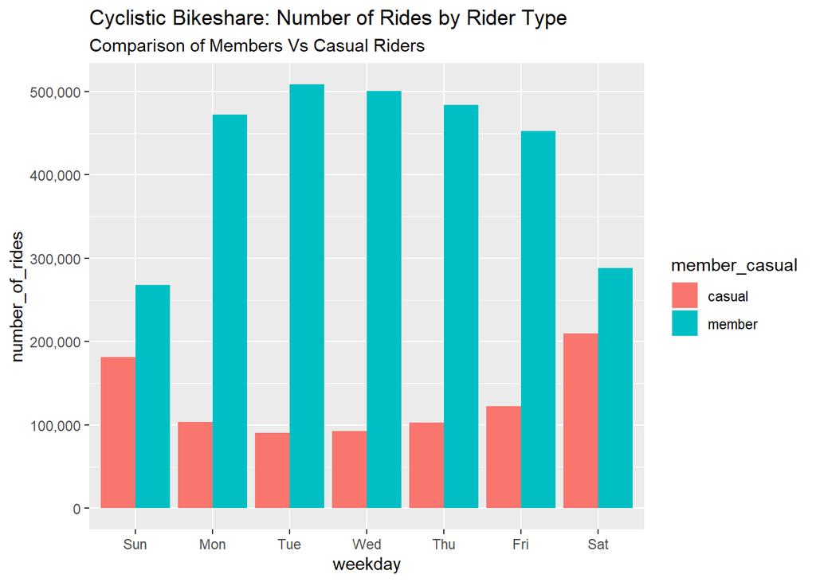

```r
cyclistic_biketrips_v2 %>%
  mutate(weekday =wday(started_at,label= TRUE)) %>%
  group_by(member_casual,weekday) %>%
  summarise(number_of_rides =n(), average_duration =mean(ride_length)) %>%
 arrange(member_casual,weekday)%>%
  ggplot(mapping = aes(x=weekday,y= number_of_rides,fill = member_casual))+
  geom_col (position = "dodge")+
  scale_y_continuous(labels = scales::comma)+
  labs(title = "Cyclistic Bikeshare: Number of Rides by Rider Type", subtitle = "Comparison of Members Vs Casual Riders")
```

```r
# Here after running and visualizing the data i ran into a problem. The values in y axis are too long and were written in scientific notation on the y axis. You cant easily make sense of the data in this format right? Imagine values written as 5E+05!!!. So i installed and loaded the scales package to the library in order to take advantage of the scale_y_continuous() function. This assisted me to be able view the actual values and make sense out of them.Just want to experiment? delete the last code line and run the chunk again.
```

# Let’s create a visualization for average duration

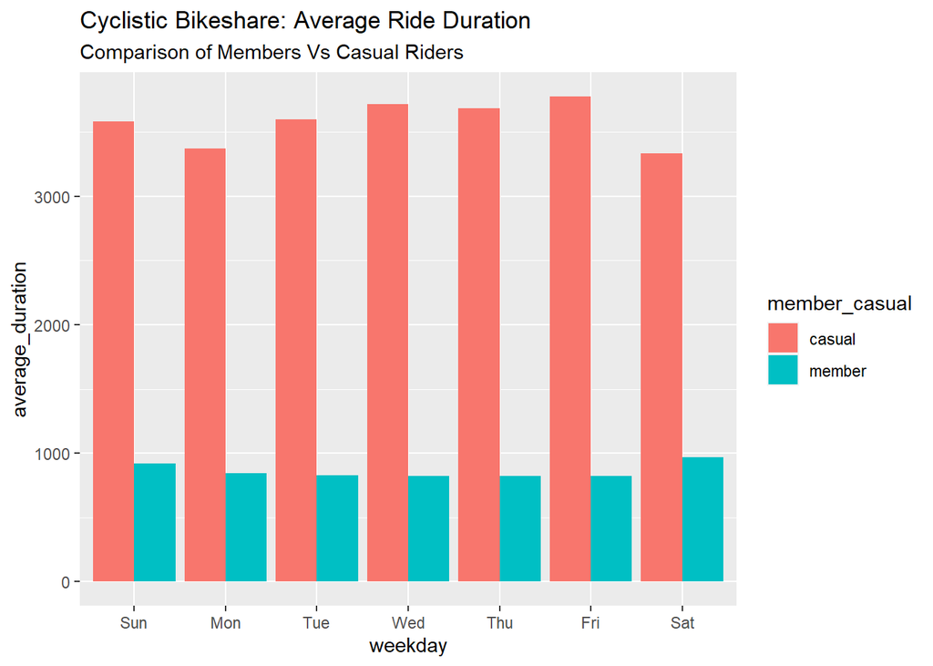

```r
cyclistic_biketrips_v2 %>%
  mutate(weekday =wday(started_at,label= TRUE)) %>%
  group_by(member_casual,weekday) %>%
  summarise(number_of_rides =n(), average_duration =mean(ride_length)) %>%
 arrange(member_casual,weekday)%>%
  ggplot(mapping =aes(x =weekday,y = average_duration, fill= member_casual)) + geom_col (position =  "dodge")+
  labs(title = "Cyclistic Bikeshare: Average Ride Duration", subtitle = "Comparison of Members Vs Casual Riders")
```

#### EXPORT SUMMARY FILE FOR FURTHER ANALYSIS

2. CSV file called bikeshare_select which was composed of few columns of interest. In this case the memmber_casual, ride_length and day_of_week. This dataset would work well with my laptop in excel.

# Data Analysis Findings

Now that the project is complete.All the data cleaning efforts data wrangling and manipulation were informed by the business task at hand. The business task was to assist the Cyclistic company to answer certain questions which would subsequently inform designing a strategy to attract and convert the casual riders into members. As the CEO Moreno said, “The future of the Cyclistic company depends or relies on the members riders. Therefore, now its time to inform the CEO the findings from the data, answer the raised questions as well as give further recommendations.

# Question 1

#### How do annual members and casual riders use Cyclistic bikes differently?

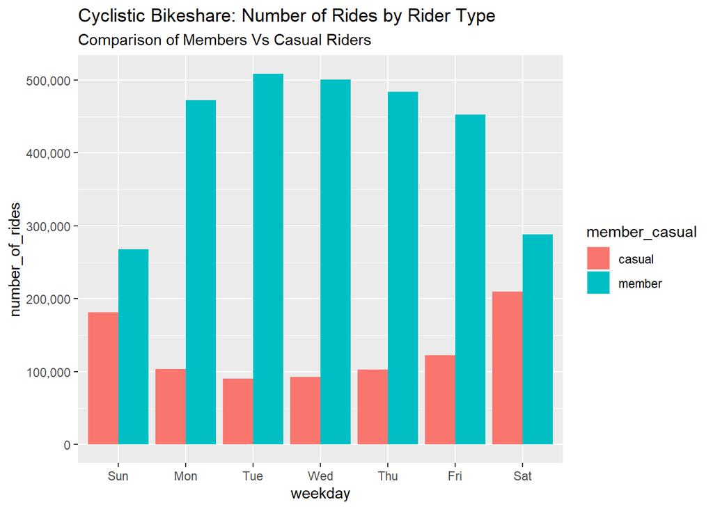

#### Casual Riders

1.The data reveals that casual riders generally have less trips than the member riders. Their most busy days are on weekends (Sunday and Saturday) with 181 293 and 209 543 rides respectively. During mid week, casual riders seem to have few rides with trips ranging between 122 404 and 90 510 trips. This therefore suggest that casual riders use the bikes and have mpre trips during weekends and to be specific, Saturday is their busiest day.

# Question 2

#### Why would casual riders buy Cyclistic annual memberships?

Based on the findings from the data, casual riders are satisfied with the casual rider terms and conditions. They make sure they get value from the money or subscription paid by fully utilizing the allocated hours or a day as justified by the highest average ride duration. In order to attract casual riders to buy membership, Cyclistic company need to review the terms and conditions for the casual ridership package. At this point, will jump to the recommendation for Cyclistic company to consider as possible strategies to attract casual rider to buy membership.

# Recommendations

1.Review the casual rider terms and conditions and benefits. The current package for casual subscribers suggests that they are content with it and they love to fully exhaust their subscription than return a bike before the subscribed hour or day comes to an end.

2.Allow and advertise to casual members only a discounted short term package where by they will be allowed as members to keep the bike (tracked bike) with them over the weekend (on Sunday and Saturday to be particular).These are the two days whereby they use bikes more than other days.Allowing them to keep the bikes for the weekend would attract them to buy membership. Though the dataset lacked more biographical data for the all the groups, one thing which need to be considered is the profile for casual riders i.e the pattern suggest they work during midweek and only on weekends they are free(more data is needed to confirm this).

3.Collect demographical data for casual riders. Currently, Cyclistic company collects demographical data for members only. Through this way also negating an opportunity to gain more insights into the casual riders.

4.Set a limit on distance traveled by casual riders and at the same time set the distance for members as unlimited and also sell the package to all casual rider through email, sms, and phone calls as well as when they make bookings

# Conclusion

In conclusion, the members and casual riders use the rented bikes differently based on trip duration, number of trips, and also they different based on the day of the week.In order to attract more casual riders to purchase membership, Cyclistic company should customize some packages that speak to the casual riders. Focusing on their tendencies to use bikes during weekends and also having long rides. Furthermore, the company need to utilize the opportunity to collect more demographical data for casual riders, this data will give more insight into the casual riders, for instance DOB, employment status. This will assist in customizing more strategies and packages that attractive to casual riders.